# Final Project

Jordan Denish and Malcolm Mashig

5/7/2020

DS 4001 Final Project: Data Visualization for our Capstone Project

# Introduction

For this final project, we want to create an interactive data visualization for a Capstone group project that we worked on throughout the semester. We have developed a Shiny Application on R using the information from class lectures and by teaching ourselves how Shiny works online. We are very excited about this application because it is much easier for people to use our app than read our 20 page report.

### Question and Background Information

For our capstone project, we wanted to analyze Major League Baseball, hoping to use historical data and various statistics in order to predict player value and make conclusions about the sport. We narrowed our focus to be more specific, ultimately choosing to analyze and project future performance of starting pitchers. Our inspiration for picking this particular position came from the fact that starting pitchers have become increasingly important and prominent among playoff contending teams. The Washington Nationals, the winner of the 2019 World Series were anchored by three elite, highly-paid starting pitchers in Max Scherzer, Stephen Strasburg, and Patrick Corbin.

Furthermore, the size and length of the contracts that teams are giving to starting pitchers are tremendously large. This past winter, during baseball’s free agency, over 1 billion dollars was spent on starting pitchers, the most free agency dollars spent on starting pitchers in baseball history. Free agent Gerrit Cole signed a nine-year, 324 million dollar contract with the New York Yankees, which is the largest deal ever signed by a pitcher. Gerrit Cole is currently 29 years old, which is considered to be one of the prime years for a starting pitcher, but he will be 38 years old at the end of his contract, when most pitchers are already in decline and considering retirement. Only the big market baseball teams like New York, Los Angeles, and Philadelphia have the spending capabilities to afford these massive free agent signings, while the smaller market teams like Tampa Bay and Oakland must find cheap alternatives in order to be able to compete. This relatively recent trend in the importance that the sport is placing on finding valuable starting pitching led us to make it the concentration of our capstone project.

After refining our ideas, we gathered data relevant to our project. We took the approach of collecting a large amount of data, hoping this would help us further revise and pinpoint a particular question of interest. A website called FanGraphs was very helpful in this data collection process, containing seemingly every imaginable statistic for every player, separated by season. The site also provided the ability for us to filter the data based on position and various other criteria and easily export the data as a CSV formatted file. We harvested all available starting pitcher data, with two significant constraints. First, we limited how far back our data went to the year 2002. Knowing that only somewhat recent data would be useful for drawing conclusions about the future, coupled with the fact that several advanced baseball metrics, such as xFIP and BABIP, have only been tracked since 2002, it made sense to cut the data off at this year. Our other constraint was that we limited the data to the seasons where the pitcher threw at least 80 innings. Though this admittedly is a somewhat arbitrary cutoff, our experimentation found that this excluded artificially short seasons, usually due to injury, while still providing a large amount of data to analyze. Further, after substantial back and forth consideration about whether to consider injuries, we decided not to pursue this analysis, as the extreme amount of randomness in injuries would likely prevent us from coming away with any meaningful results. Thus, our complete data set included all relevant performance statistics for each season with at least 80 innings pitched for every starting pitcher from 2002-2019.

### Exploratory Data Analysis

As you can see by the change in fastball velocity and xFIP since 2002, the percentiles have kept a consistent distance. This shows us that standardizing variables like fastball velocity and xFIP will help to mitigate the influence of changes in the game of baseball over time on our analysis. We standardized nearly all of our variables to account for this variation.

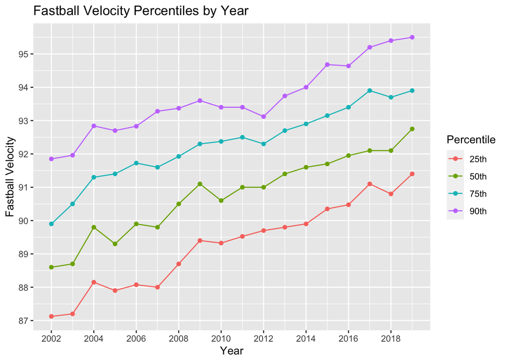

```r
plot1
```

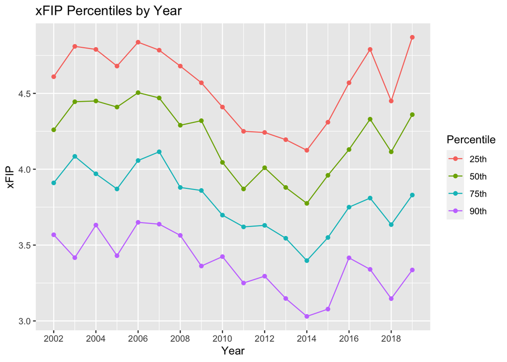

```r
plot3
```

The plots below show the characteristics of the fastball velocity and xFIP variables. We know from them that fastball velocity generally declines as a pitcher ages, which is expected, and that the change in xFIP for players at a certain age has a generally normal distribution. This was the case for players at the age of 28 and at most other ages

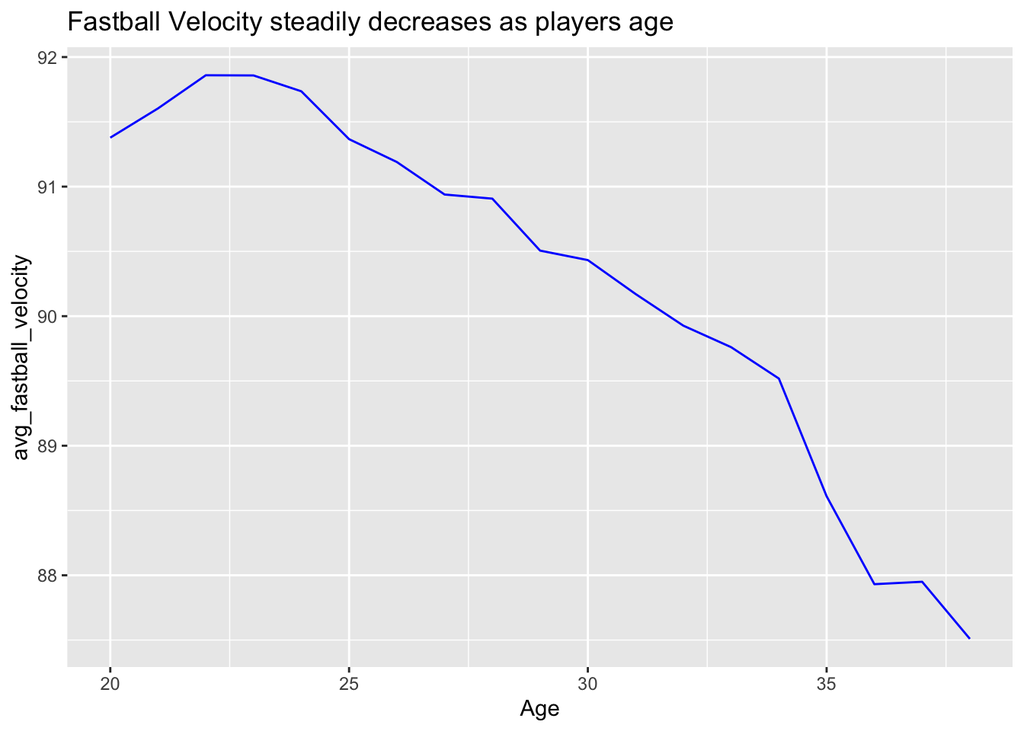

```r
fangraphs_clean %>%
      group_by(Age) %>%
      summarise(avg_fastball_velocity = mean(FBv, na.rm = TRUE)) %>%
      filter(between(Age, 20, 38)) %>%
      ggplot() +
      geom_line(aes(Age, avg_fastball_velocity), color = "blue") +
      labs(title = "Fastball Velocity steadily decreases as players age")
```

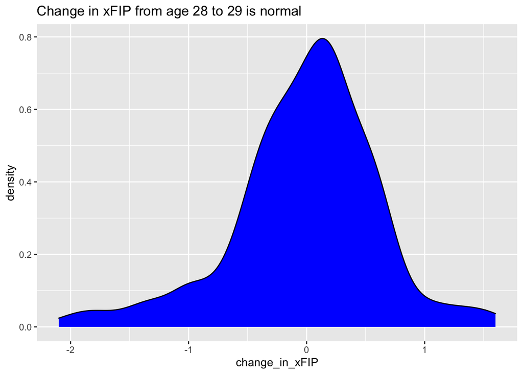

```r
fangraphs_clean %>%
      mutate(change_in_xFIP = lead(xFIP) - xFIP) %>%
      filter(Age == 28) %>%
      ggplot() +
      geom_density(aes(change_in_xFIP), fill = "blue") +
      labs(title = "Change in xFIP from age 28 to 29 is normal")
```

### xFIP

One of the most important decisions we had to make as a group was choosing which metric to evaluate pitchers on, as there are many such statistics that each have strengths and weaknesses. We wanted to choose a metric that was descriptive, in that it encapsulates valuable information, and predictive, in that it is relatively stable year-to-year. The traditional metric for measuring pitcher success is Earned Run Average (ERA), an easy to understand statistic which simply divides the number of earned runs a pitcher allows by the number of innings he pitches, and then multiplies this average by nine to mimic the length of a baseball game. ERA makes sense as a critical performance measure, as a pitcher’s primary goal for his team is to prevent runs, and a pitcher’s ERA will show how effective he was. However, ERA has many issues that have caused most baseball analysts to move beyond it.

For one, the fielding of the team around a pitcher is not included in the metric, which certainly has an impact on the number of runs that he gives up. A pitcher with a better defense is more likely to have a lower ERA than a pitcher with a worse defense. Another negative aspect of ERA is that it includes no information about the ballpark that the pitcher plays in. For instance, Coors Field of the Colorado Rockies is notoriously easy to hit home runs in, as balls fly farther in the high elevation of Denver. On the other end of the spectrum, Petco Park of the San Diego Padres has deep fences and a spacious outfield which are hostile to hitters. Since the environment that pitchers play in varies so much from pitcher to pitcher, a metric like ERA has major flaws that make it difficult to encapsulate a pitcher’s true value. Due to these flaws, we eventually decided to use a statistic named Expected Fielding Independent Pitching (xFIP), which is an advanced baseball statistic that is an estimate for a pitcher’s earned run average (ERA). A pitcher’s main objective is to prevent runs and xFIP is considered to be a better predictor of future performance than ERA, which can mask the actual skill of a pitcher. xFIP is a common estimate for a pitcher’s ERA that only factors in the batter outcomes that a pitcher can control (strikeouts, walks, and hit by pitches) while also normalizing for home runs allowed by using the league average home run/fly ball rate. xFIP is calculated using the formula xFIP = ((13*(Fly balls* lgHR/FB%))+(3*(BB+HBP))-(2*K))/IP + constant. The constant is generally around 3.10, which helps adjust the xFIP value to an ERA scale.

### Research Question

Once we were satisfied and confident in using xFIP as our performance metric, we were able to clearly state our research question: Can we accurately predict an MLB starting pitcher’s future xFIP over the next few seasons using various performance statistics from prior seasons in order to estimate relative future value of the pitcher? Simply put, we wanted to create a model that could take any pitcher, along with the statistics of all of their previous seasons, as an input and make projections for the xFIP of their next few seasons. From our main research question, two sub-questions naturally emerged as well. In particular, we wanted to look at how pitchers “aged”, or how their performance was affected as they got older, as well as whether all prior seasons were equally predictive or if more recent seasons were more important predictors of future xFIP. Our data set provided us with all of the relevant and necessary information to model xFIP over time, as well as answer our sub-questions. Further, viewing our data as a sample of the population of all starting pitcher seasons with at least 80 innings pitched, both past and future, we will be able to generalize our results to future seasons.